# Struggles with Remote Work

Section 1: Intro and Data

Michael Foley

8/1/2021

Buffer published [The 2021 State of Remote Work](https://buffer.com/2021-state-of-remote-work), a summary of a survey of over 2,000 remote workers in late 2020. The report was a follow up to the [2020 report](https://lp.buffer.com/state-of-remote-work-2020) which was featured in [MakeoverMonday](https://data.world/makeovermonday/2020w32). Buffer made the 2021 report data available as a Google sheets file on Google Docs.

The Buffer survey found that workers overwhelmingly support remote work. However, they did share struggles such as difficulty unplugging from the office, collaborating, and loneliness. I am curious what factors impact their struggles.

In this section, I pull the 2021 report data from Google Docs and prepare it for analysis in the subsequent sections. Subsequent sections explore and analyze the survey results.

## File Download

The file is located on Google Docs.

```r
# not using a private sheet, so no need for token
googlesheets4::gs4_deauth()

buffer_0 <- googlesheets4::read_sheet(
  buffer_url,
  range = "CompleteData!B3:AS2248",
  col_names = codebook$item,
  col_types = paste(codebook$resp_type, collapse = ""))
## Reading from "Open - 2021 State of Remote Work"
## Range "'CompleteData'!B3:AS2248"

dim(buffer_0)
## [1] 2246   44
```

I hand-made a code book to translate the full question text into short variable names. There are 44 variables in the data file.

```r
codebook %>%
  select(-resp_type) %>%
  flextable() %>%
  autofit() %>%
  theme_zebra() %>%
  set_caption("Codebook.")
```

Codebook.

| item | desc |
| --- | --- |
| country | What country do you live in currently? |
| industry | What industry do you work in? |
| industry_other | Other |
| role | In the following list, what best describes the work you do? |
| role_other | Other |
| race | Which of the following best describes you? |
| race_other | Other |
| work_exp | How long have you been in the workforce? |
| remote_exp | How long have you worked remotely? |
| disability | Do you have a disability or chronic illness? |
| disability_remote | Is a disability or chronic illness one of the reasons you pursued remote work? |
| caregiver | Are you a parent or caregiver? |
| caregiver_remote | Is being a parent or caregiver one of the reasons you pursued remote work? |
| prefer_remote | Would you like to work remotely, at least some of the time, for the rest of your career? |
| recommend_remote | Would you recommend remote work to others? |
| struggle | What’s your biggest struggle with working remotely? |
| struggle_other | Other |
| benefit | What’s the biggest benefit you see to working remotely? |
| benefit_other | Other |
| covid | Are you working remotely as a result of COVID-19? |
| permanent | Is your company planning on permanently allowing remote work? |
| return | When will you be returning to your workspace and no longer be allowed to work remotely? |
| smooth | Was your company's transition to remote work smooth? |
| smooth_why | What made it smooth? |
| smooth_not | Why not? |
| change | What has changed the most about your work now that you work remotely? |
| change_other | Other |
| work_less_more | Would you say you are working less or more now that you work remotely? |
| meet_more | Do you find you are in more meetings as a result of the shift to remote work? |
| other_changes | Is there anything else you'd like to add about how your work has changed now that you work remotely? |
| emp_type | Which description best suits you? |
| time_zones | Is your company operating in multiple time zones? |
| time_zones_cnt | How many time zones do employees at your company span? |
| time_zones_team | Are people on your immediate team in multiple time zones? |
| asynch | Does your company encourage asynchronous communication? |
| fte | How many full-time employees does your company have? |
| pct_remote | What percentage of your company works remotely? |
| pay_internet | If you work from home, does your company pay for your home internet? |
| pay_cell | Does your company pay for your cell phone? |
| pay_membership | Does your company cover the cost of a coworking membership? |
| pay_computer | Does your company cover your necessary hardware needs? |
| pay_software | Does your company cover your necessary software needs? |
| pay_other | Are there any other costs of working remotely that your company covers? |
| other | Anything else you want to add that we didn’t ask about? |

## Delete Empty Rows

Several records are completely empty. They are easily spotted as having no value in the first column (country).

```r
buffer_1 <- buffer_0 %>%
  filter(!is.na(country))

dim(buffer_1)
```

```
## [1] 2218   44
```

There were 28 empty rows. Removing them reduces our data set from 2,246 rows to 2,218 rows.

## Remove “Other” Cols

Several multiple-choice questions have a free-form “other” option and an accompanying variable for the free-form text response.

```r
codebook %>%
  filter(str_detect(item, "other") & !(item %in% c("other", "pay_other"))) %>%
  select(-resp_type)
```

```
## # A tibble: 7 x 2
##   item          desc
##   <chr>         <chr>
## 1 industry_oth~ Other
## 2 role_other    Other
## 3 race_other    Other
## 4 struggle_oth~ Other
## 5 benefit_other Other
## 6 change_other  Other
## 7 other_changes Is there anything else you'd like to add about how your work ha~
```

There won’t be much predictive power in these “other” values, so I will replace the nulls with the string “Other”, and remove the accompanying free-form text columns.

```r
buffer_2 <- buffer_1 %>%
  replace_na(list(industry = "Other",
                  role = "Other",
                  race = "Other/Unk",
                  struggle = "Other",
                  benefit = "Other",
                  change = "Other"
                  )) %>%
  select(-contains("other"), other, pay_other)

dim(buffer_2)
```

```
## [1] 2218   37
```

Dropping these 7 columns reduces our data set from 44 cols to 37 cols.

## Remove Uninteresting Cols

Several questions ask about the time-zone distribution of company employees and remote-work costs covered by the company.

```r
codebook %>%
  filter(str_detect(item, "^pay|(time_zones)|(^asynch)")) %>%
  select(-resp_type)
```

```
## # A tibble: 10 x 2
##    item           desc
##    <chr>          <chr>
##  1 time_zones     Is your company operating in multiple time zones?
##  2 time_zones_cnt How many time zones do employees at your company span?
##  3 time_zones_te~ Are people on your immediate team in multiple time zones?
##  4 asynch         Does your company encourage asynchronous communication?
##  5 pay_internet   If you work from home, does your company pay for your home in~
##  6 pay_cell       Does your company pay for your cell phone?
##  7 pay_membership Does your company cover the cost of a coworking membership?
##  8 pay_computer   Does your company cover your necessary hardware needs?
##  9 pay_software   Does your company cover your necessary software needs?
## 10 pay_other      Are there any other costs of working remotely that your compa~
```

These questions are not useful for my analysis, so I’ll drop them.

```r
buffer_3 <- buffer_2 %>%
  select(-starts_with(c("pay", "time", "asynch")))

dim(buffer_3)
```

```
## [1] 2218   27
```

Dropping these 10 columns reduces our data set from from 37 cols to 27 cols.

## Remove Free-Form Cols

There are a few other free-form survey items.

```r
codebook %>%
  filter(item %in% c("smooth_why", "smooth_not", "change", "other")) %>%
  select(-resp_type)
```

```
## # A tibble: 4 x 2
##   item       desc
##   <chr>      <chr>
## 1 smooth_why What made it smooth?
## 2 smooth_not Why not?
## 3 change     What has changed the most about your work now that you work remote~
## 4 other      Anything else you want to add that we didn’t ask about?
```

None of these are useful for my analysis so I will drop them too.

```r
buffer_4 <- buffer_3 %>%
  select(-c(smooth_why, smooth_not, change, other))

dim(buffer_4)
```

```
## [1] 2218   23
```

Dropping these 4 columns reduces our data set from 27 to 23 cols.

## Remove Sparse Cols

A few columns are more than 50% empty.

```r
(na_vars <- buffer_4 %>%
   skimr::skim() %>%
   filter(complete_rate < .5) %>%
   as.data.frame() %>%
   select(skim_variable, n_missing, complete_rate))
```

```
##       skim_variable n_missing complete_rate
## 1         permanent      1241    0.44048693
## 2            return      2061    0.07078449
## 3    work_less_more      1229    0.44589720
## 4 disability_remote      2033    0.08340848
## 5  caregiver_remote      1436    0.35256988
## 6            smooth      1228    0.44634806
## 7         meet_more      1231    0.44499549
```

Imputing values is possible, but I’m less concerned with prediction than I am with understanding variable importance. I’ll remove them.

```r
buffer_5 <- buffer_4 %>%
  select(-na_vars$skim_variable)
```

Dropping these 7 columns reduces our data set from 23 cols to 16 cols.

## Characters to Factors

Most of the character fields need to be factors if they are going to be useful in models.

```r
buffer_6 <- buffer_5 %>%
  mutate(race = factor(case_when(race == "Asian or Pacific Islander" ~ "Asian",
                                 race == "Black or African American" ~ "Black",
                                 race == "Hispanic or Latino" ~ "Hispanic",
                                 race == "Multiracial or Biracial" ~ "Multiracial",
                                 race == "Native American or Alaska Native" ~ "Other/Unk",
                                 TRUE ~ race),
                       levels = c("White", "Black", "Hispanic", "Asian", "Multiracial", "Other/Unk")),
         work_exp = factor(work_exp, levels = c("Less than six months",
                                                "6 months - 11 months",
                                                "1 year - 4 years",
                                                "5 years - 9 years",
                                                "10 years - 14 years",
                                                "15 years - 19 years",
                                                "More than 20 years"),
                           ordered = TRUE),
         remote_exp = factor(remote_exp, levels = c("Less than six months",
                                                "6 months to 11 months",
                                                "1 year to 4 years",
                                                "5 years - 9 years",
                                                "More than 10 years")),
         disability = factor(disability, levels = c(0, 1), labels = c("No", "Yes")),
         emp_type = factor(emp_type, levels = c("Business owner",
                                                "Employee",
                                                "Freelancer / Self-employed"),
                           labels = c("Business Owner", "Employee", "Self-Employed")),
         role = case_when(role == "Customer Support" ~ "CSR",
                          role == "Human Resources" ~ "HR",
                          role == "Marketing and Advertising" ~ "Marketing",
                          TRUE ~ role),
         role = fct_relevel(role, "Other", after = Inf),
         covid = factor(covid, levels = c(0, 1), labels = c("Not Related", "COVID-Related")),
         prefer_remote = factor(prefer_remote, levels = c(0, 1), labels = c("No Remote", "Prefer")),
         recommend_remote = factor(recommend_remote, levels = c(0, 1), labels = c("No Remote", "Recommend")),
         caregiver = factor(caregiver,
                            levels = c(0, 1),
                            labels = c("Not Caregiver", "Caregiver")),
         benefit = factor(benefit,
                          levels = c("Ability to have a flexible schedule",
                                     "Ability to spend time with family",
                                     "Ability to work from home",
                                     "Flexibility to work from any location",
                                     "Not having to commute",
                                     "Other"),
                          labels = c("Flexible Schedule", "Time with Family",
                                     "Work from Home", "Flexible Location",
                                     "No Commute", "Other")),
         industry = factor(industry),
         fte = factor(fte, levels = c("Just me",
                                      "Fewer than 10",
                                      "11 to 50",
                                      "51 to 100",
                                      "101 to 500",
                                      "501 to 1,000",
                                      "More than 1,001")),
         pct_remote = factor(pct_remote, levels = c("1 to 25%",
                                                    "26 to 50%",
                                                    "51 to 75%",
                                                    "76 to 99%",
                                                    "100%")),
         struggle = factor(struggle,
                           levels = c("Being in a different timezone than teammates",
                                      "Difficulties with collaboration and communication",
                                      "Distractions at home",
                                      "Loneliness",
                                      "Not being able to unplug",
                                      "Staying motivated",
                                      "Other"),
                           labels = c("Timezones", "Collaboration",
                                      "Distractions", "Loneliness", "Unplugging",
                                      "Motivation", "Other"))) %>%
         select(-contains("other"), -contains("time_zones"), -starts_with("pay"))
```

## Impute Null Values

Some values are null, but might be inferred as another value. I’ll use the mode values for `disability` and `caregiver`.

```r
buffer_7 <- buffer_6 %>%
  replace_na(list(disability = "No",
                  caregiver = "Not Caregiver"))
```

I’ll use **mice** (Multivariate Imputations by Chained Equations) to impute `fte` and `pct_remote`.

```r
mice_obj <- mice(buffer_7)
buffer_8 <- complete(mice_obj)
```

Let’s see how it did.

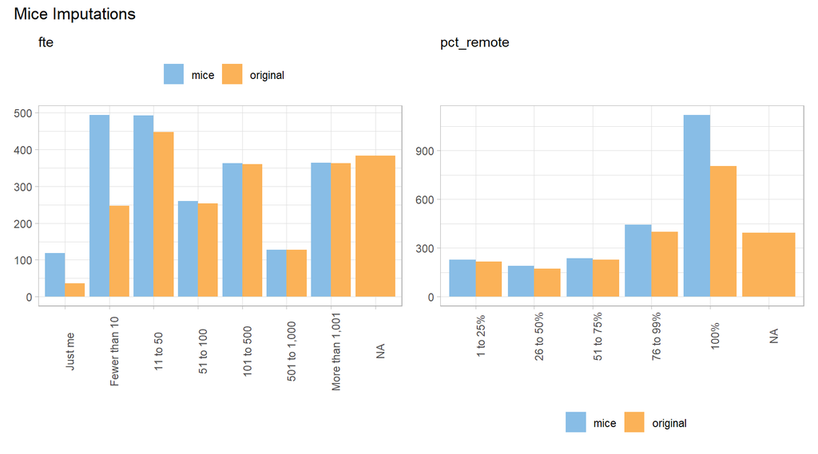

```r
p1 <- data.frame(original = buffer_7$fte, mice = buffer_8$fte) %>%
  pivot_longer(cols = c("original", "mice"), names_to = "Data", values_to= "Fare") %>%
  ggplot(aes(x = Fare, fill = Data)) +
  geom_bar(na.rm = TRUE, position = position_dodge()) +
  ggthemes::scale_fill_few() +
  theme_light() +
  theme(legend.position = "top",
        axis.text.x = element_text(angle = 90)) +
  labs(subtitle = "fte", x = NULL, y = NULL, fill = "")

p2 <- data.frame(original = buffer_7$pct_remote, mice = buffer_8$pct_remote) %>%
  pivot_longer(cols = c("original", "mice"), names_to = "Data", values_to= "Fare") %>%
  ggplot(aes(x = Fare, fill = Data)) +
  geom_bar(na.rm = TRUE, position = position_dodge()) +
  ggthemes::scale_fill_few() +
  theme_light() +
  theme(legend.position = "bottom",
        axis.text.x = element_text(angle = 90)) +
  labs(subtitle = "pct_remote", x = NULL, y = NULL, fill = "")

p1 + p2 +
  patchwork::plot_annotation(title = "Mice Imputations")
```

## Final Look

That’s it for the data cleaning. Let’s have a final look at the data before moving on.

```r
skimr::skim(buffer_8)
```

Data summary

| Name | buffer_8 |
| --- | --- |
| Number of rows | 2218 |
| Number of columns | 16 |
| _______________________ |  |
| Column type frequency: |  |
| character | 1 |
| factor | 15 |
| ________________________ |  |
| Group variables | None |

**Variable type: character**

| skim_variable | n_missing | complete_rate | min | max | empty | n_unique | whitespace |
| --- | --- | --- | --- | --- | --- | --- | --- |
| country | 0 | 1 | 5 | 20 | 0 | 89 | 0 |

**Variable type: factor**

| skim_variable | n_missing | complete_rate | ordered | n_unique | top_counts |
| --- | --- | --- | --- | --- | --- |
| industry | 0 | 1 | FALSE | 14 | Sof: 821, IT : 403, Mar: 240, Oth: 149 |
| role | 0 | 1 | FALSE | 12 | Eng: 725, Mar: 398, Lea: 193, Des: 157 |
| race | 0 | 1 | FALSE | 6 | Whi: 1605, Asi: 220, His: 206, Mul: 63 |
| work_exp | 0 | 1 | TRUE | 7 | 5 y: 574, 10 : 512, 1 y: 355, 15 : 347 |
| remote_exp | 0 | 1 | FALSE | 5 | 1 y: 749, 6 m: 712, 5 y: 431, Les: 174 |
| disability | 0 | 1 | FALSE | 2 | No: 2033, Yes: 185 |
| caregiver | 0 | 1 | FALSE | 2 | Not: 1434, Car: 784 |
| prefer_remote | 0 | 1 | FALSE | 2 | Pre: 2165, No : 53 |
| recommend_remote | 0 | 1 | FALSE | 2 | Rec: 2150, No : 68 |
| struggle | 0 | 1 | FALSE | 7 | Unp: 591, Col: 362, Lon: 351, Dis: 333 |
| benefit | 0 | 1 | FALSE | 6 | Fle: 708, Fle: 562, No : 494, Tim: 238 |
| covid | 0 | 1 | FALSE | 2 | Not: 1228, COV: 990 |
| emp_type | 0 | 1 | FALSE | 3 | Emp: 1649, Sel: 383, Bus: 186 |
| fte | 0 | 1 | FALSE | 7 | Few: 494, 11 : 492, Mor: 364, 101: 362 |
| pct_remote | 0 | 1 | FALSE | 5 | 100: 1120, 76 : 444, 51 : 237, 1 t: 227 |

The only remaining character type is `country`. I’ll probably drop that from models. The `industry` and `role` factors have a lot of levels. I might need to collapse levels or exclude them from the model, depending on what I learn from the data exploration step.

## Save Data

I’ll save my work for the next step.

```r
saveRDS(buffer_8, file = "./buffer.rds")
saveRDS(codebook, file = "./codebook.rds")
```